# Forecast daily bike rental demand using time series models

Shivam Srivastava

22 July 2025

# About Data Analysis Report

This RMarkdown file contains the report of the data analysis done for the project on forecasting daily bike rental demand using time series models in R. It contains analysis such as data exploration, summary statistics and building the time series models. The final report was completed on Tue Jul 22 15:46:04 2025.

**Data Description:**

This dataset contains the daily count of rental bike transactions between years 2011 and 2012 in Capital bikeshare system with the corresponding weather and seasonal information.

**Data Source:** https://archive.ics.uci.edu/ml/datasets/bike+sharing+dataset

**Relevant Paper:**

Fanaee-T, Hadi, and Gama, Joao, ‘Event labeling combining ensemble detectors and background knowledge’, Progress in Artificial Intelligence (2013): pp. 1-15, Springer Berlin Heidelberg

# Task One: Load and explore the data

## Load data and install packages

```r
## Import required packages
install.packages("tidyverse")
install.packages("forecast")
install.packages("lubridate")
```

```r
install.packages("ggplot2")
install.packages("timetk")
# Load required packages
library(tidyverse)
library(forecast)
library(lubridate)
library(ggplot2)
library(timetk)

#Load dataset
bike_sharing_daily <- read_csv("bike_sharing_daily.csv")
## Describe and explore the data

names(bike_sharing_daily)
```

```
##  [1] "instant"    "dteday"     "season"     "yr"         "mnth"
##  [6] "holiday"    "weekday"    "workingday" "weathersit" "temp"
## [11] "atemp"      "hum"        "windspeed"  "casual"     "registered"
## [16] "cnt"
```

```r
# View(bike_sharing_daily)

 str(bike_sharing_daily)
```

```
## spc_tbl_ [731 × 16] (S3: spec_tbl_df/tbl_df/tbl/data.frame)
##  $ instant   : num [1:731] 1 2 3 4 5 6 7 8 9 10 ...
##  $ dteday    : Date[1:731], format: "2011-01-01" "2011-01-02" ...
##  $ season    : num [1:731] 1 1 1 1 1 1 1 1 1 1 ...
##  $ yr        : num [1:731] 0 0 0 0 0 0 0 0 0 0 ...
##  $ mnth      : num [1:731] 1 1 1 1 1 1 1 1 1 1 ...
##  $ holiday   : num [1:731] 0 0 0 0 0 0 0 0 0 0 ...
##  $ weekday   : num [1:731] 6 0 1 2 3 4 5 6 0 1 ...
##  $ workingday: num [1:731] 0 0 1 1 1 1 1 0 0 1 ...
##  $ weathersit: num [1:731] 2 2 1 1 1 1 2 2 1 1 ...
##  $ temp      : num [1:731] 0.344 0.363 0.196 0.2 0.227 ...
##  $ atemp     : num [1:731] 0.364 0.354 0.189 0.212 0.229 ...
##  $ hum       : num [1:731] 0.806 0.696 0.437 0.59 0.437 ...
##  $ windspeed : num [1:731] 0.16 0.249 0.248 0.16 0.187 ...
##  $ casual    : num [1:731] 331 131 120 108 82 88 148 68 54 41 ...
##  $ registered: num [1:731] 654 670 1229 1454 1518 ...
##  $ cnt       : num [1:731] 985 801 1349 1562 1600 ...
##  - attr(*, "spec")=
##   .. cols(
##   ..   instant = col_double(),
##   ..   dteday = col_date(format = ""),
##   ..   season = col_double(),
##   ..   yr = col_double(),
##   ..   mnth = col_double(),
##   ..   holiday = col_double(),
##   ..   weekday = col_double(),
##   ..   workingday = col_double(),
##   ..   weathersit = col_double(),
##   ..   temp = col_double(),
##   ..   atemp = col_double(),
##   ..   hum = col_double(),
##   ..   windspeed = col_double(),
##   ..   casual = col_double(),
##   ..   registered = col_double(),
##   ..   cnt = col_double()
##   .. )
##  - attr(*, "problems")=<externalptr>
```

```r
# Convert the date column to proper Date format

bike_sharing_daily$dteday <- ymd(bike_sharing_daily$dteday)

# Check structure to confirm it's working
glimpse(bike_sharing_daily)
```

```
## Rows: 731
## Columns: 16
## $ instant    <dbl> 1, 2, 3, 4, 5, 6, 7, 8, 9, 10, 11, 12, 13, 14, 15, 16, 17, …
## $ dteday     <date> 2011-01-01, 2011-01-02, 2011-01-03, 2011-01-04, 2011-01-05…
## $ season     <dbl> 1, 1, 1, 1, 1, 1, 1, 1, 1, 1, 1, 1, 1, 1, 1, 1, 1, 1, 1, 1,…
## $ yr         <dbl> 0, 0, 0, 0, 0, 0, 0, 0, 0, 0, 0, 0, 0, 0, 0, 0, 0, 0, 0, 0,…
## $ mnth       <dbl> 1, 1, 1, 1, 1, 1, 1, 1, 1, 1, 1, 1, 1, 1, 1, 1, 1, 1, 1, 1,…
## $ holiday    <dbl> 0, 0, 0, 0, 0, 0, 0, 0, 0, 0, 0, 0, 0, 0, 0, 0, 1, 0, 0, 0,…
## $ weekday    <dbl> 6, 0, 1, 2, 3, 4, 5, 6, 0, 1, 2, 3, 4, 5, 6, 0, 1, 2, 3, 4,…
## $ workingday <dbl> 0, 0, 1, 1, 1, 1, 1, 0, 0, 1, 1, 1, 1, 1, 0, 0, 0, 1, 1, 1,…
## $ weathersit <dbl> 2, 2, 1, 1, 1, 1, 2, 2, 1, 1, 2, 1, 1, 1, 2, 1, 2, 2, 2, 2,…
## $ temp       <dbl> 0.3441670, 0.3634780, 0.1963640, 0.2000000, 0.2269570, 0.20…
## $ atemp      <dbl> 0.3636250, 0.3537390, 0.1894050, 0.2121220, 0.2292700, 0.23…
## $ hum        <dbl> 0.805833, 0.696087, 0.437273, 0.590435, 0.436957, 0.518261,…
## $ windspeed  <dbl> 0.1604460, 0.2485390, 0.2483090, 0.1602960, 0.1869000, 0.08…
## $ casual     <dbl> 331, 131, 120, 108, 82, 88, 148, 68, 54, 41, 43, 25, 38, 54…
## $ registered <dbl> 654, 670, 1229, 1454, 1518, 1518, 1362, 891, 768, 1280, 122…
## $ cnt        <dbl> 985, 801, 1349, 1562, 1600, 1606, 1510, 959, 822, 1321, 126…
```

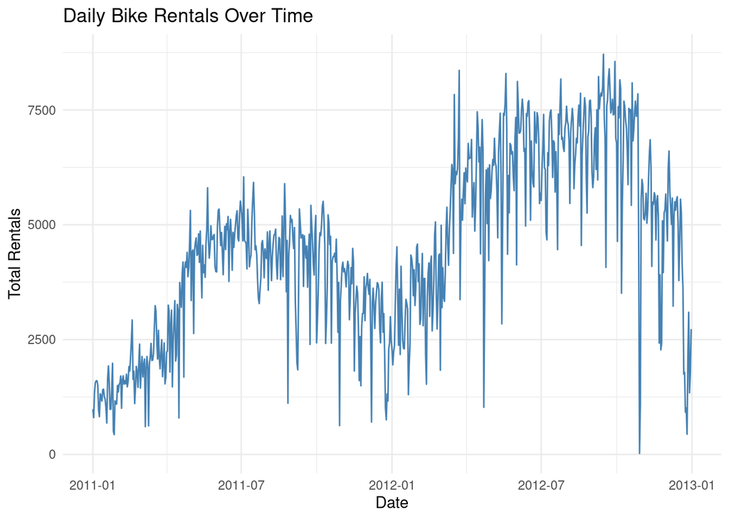

```r
# Task Two: Create interactive time series plots


# Time series line plot of daily rentals
library(readr)

ggplot(bike_sharing_daily, aes(x = dteday, y = cnt)) +
  geom_line(color = "steelblue") +
  labs(title = "Daily Bike Rentals Over Time",
       x = "Date", y = "Total Rentals") +
  theme_minimal()
```

### What Each Part Does

- `ymd(bike_sharing_daily$dteday)`: Converts date column to Date class.
- `cnt`: The total count of rentals (target variable).
- `geom_line()`: Creates the time series line.
- `theme_minimal()`: A clean, modern theme.

# Task Three: Smooth time series data

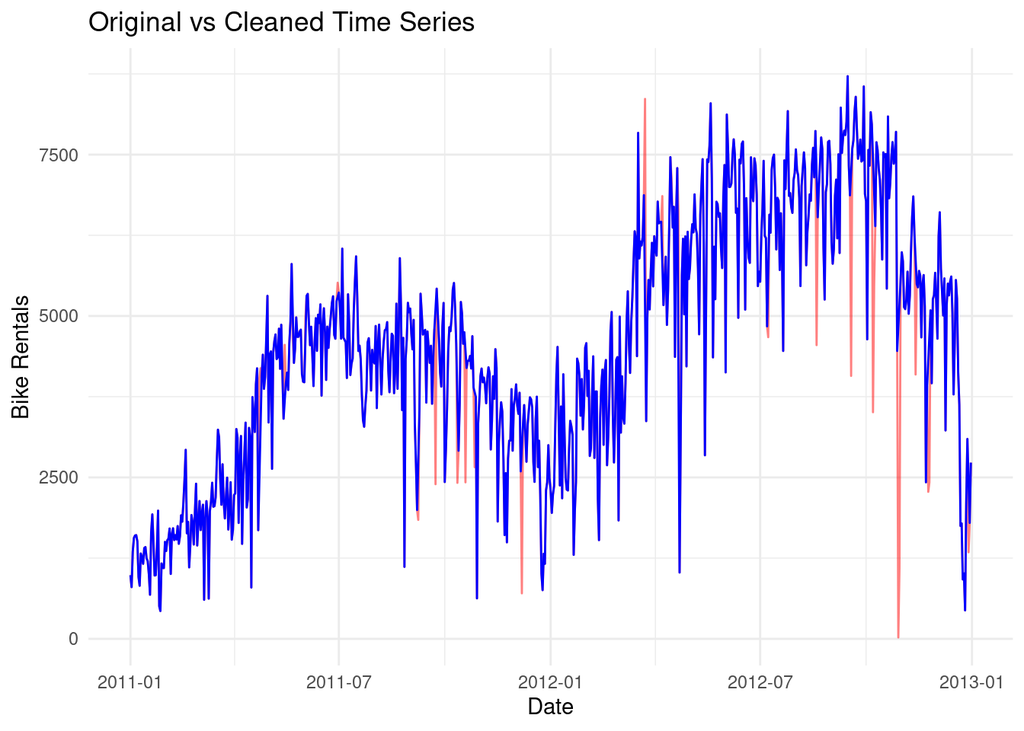

```r
ggplot(bike_sharing_daily, aes(x = dteday)) +
  geom_line(aes(y = cnt), color = "red", alpha = 0.5) +
  geom_line(aes(y = cnt_clean), color = "blue") +
  labs(title = "Original vs Cleaned Time Series",
       y = "Bike Rentals", x = "Date") +
  theme_minimal()
```

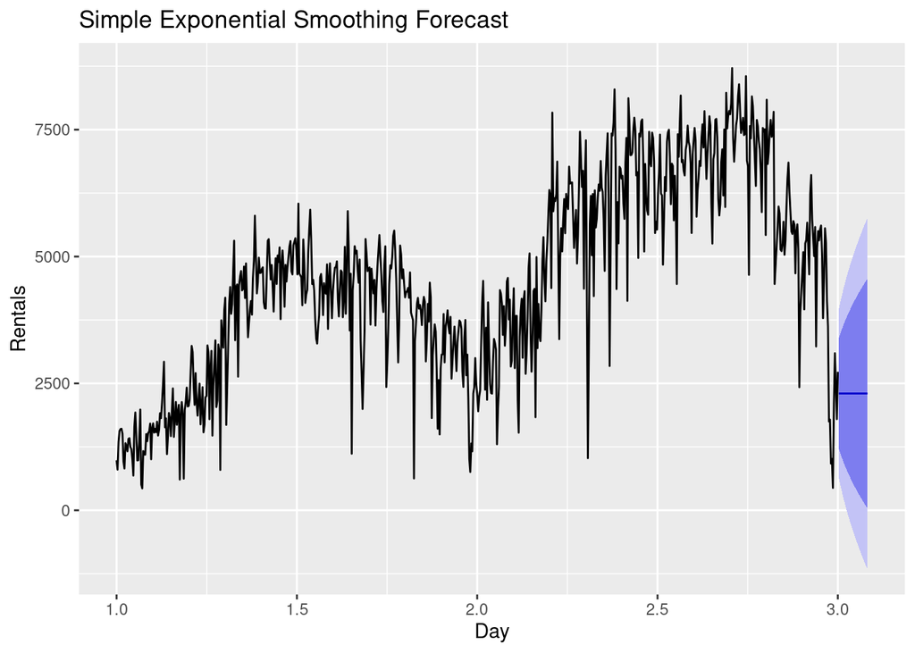

```r
# Apply simple exponential smoothing
ses_model <- HoltWinters(bike_ts_clean, beta = FALSE, gamma = FALSE)

# Forecast next 30 days
ses_forecast <- forecast(ses_model, h = 30)

# Plot forecast
autoplot(ses_forecast) +
  labs(title = "Simple Exponential Smoothing Forecast",
        y = "Rentals", x = "Day")
```

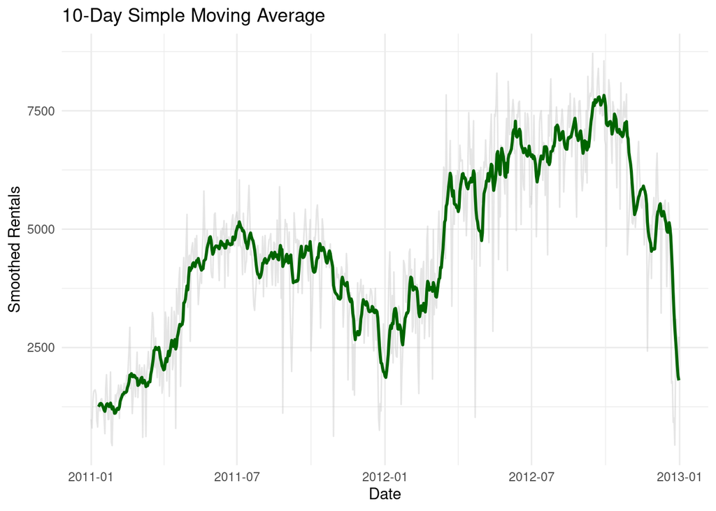

```r
# Calculate 10-day Simple Moving Average
bike_sharing_daily$sma_10 <- SMA(bike_sharing_daily$cnt_clean, n = 10)

# Plot Moving Average
ggplot(bike_sharing_daily, aes(x = dteday)) +
  geom_line(aes(y = cnt_clean), color = "gray", alpha = 0.4) +
  geom_line(aes(y = sma_10), color = "darkgreen", size = 1) +
  labs(title = "10-Day Simple Moving Average",
       y = "Smoothed Rentals", x = "Date") +
  theme_minimal()
```

# Task Four: Decompose and assess the stationarity of time series data

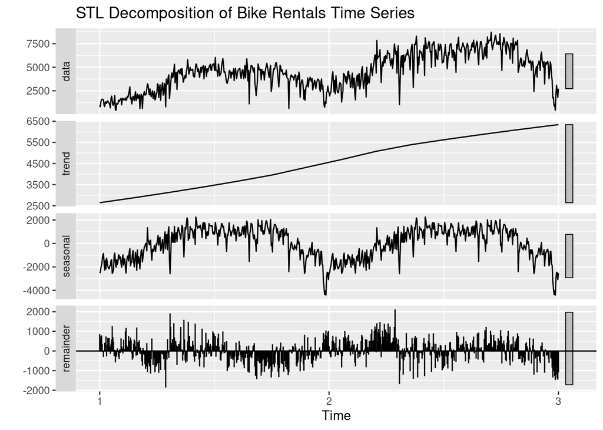

```r
# Create time series again (cleaned version from previous step)
bike_ts_clean <- ts(bike_sharing_daily$cnt_clean, frequency = 365)

# STL decomposition
decomp <- stl(bike_ts_clean, s.window = "periodic")

# Plot the decomposition
autoplot(decomp) +
  labs(title = "STL Decomposition of Bike Rentals Time Series")
```

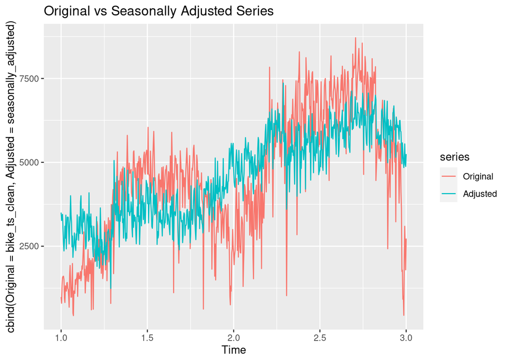

```r
# Extract seasonally adjusted data
seasonally_adjusted <- seasadj(decomp)

# Plot adjusted vs original
autoplot(cbind(Original = bike_ts_clean, Adjusted = seasonally_adjusted)) +
  labs(title = "Original vs Seasonally Adjusted Series")
```

```r
# ADF Test: Null hypothesis = NOT stationary
adf_test_result <- adf.test(seasonally_adjusted)
print(adf_test_result)
```

```
##
##  Augmented Dickey-Fuller Test
##
## data:  seasonally_adjusted
## Dickey-Fuller = -3.4248, Lag order = 9, p-value = 0.04953
## alternative hypothesis: stationary
```

- **p-value > 0.05** → Data is **non-stationary**
- **p-value < 0.05** → Data is **stationary**

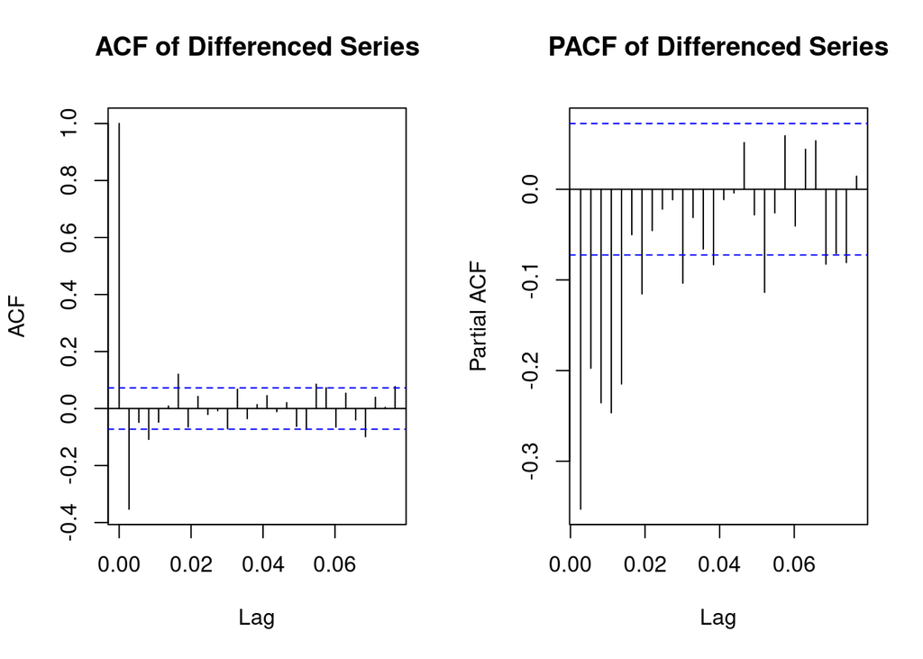

```r
# Apply first differencing
diff_1 <- diff(seasonally_adjusted, differences = 1)
# Plot ACF and PACF
par(mfrow = c(1, 2))
acf(diff_1, main = "ACF of Differenced Series")
pacf(diff_1, main = "PACF of Differenced Series")
```

```r
par(mfrow = c(1, 1))

# ADF test after differencing
adf.test(diff_1)
```

```
##
##  Augmented Dickey-Fuller Test
##
## data:  diff_1
## Dickey-Fuller = -13.301, Lag order = 8, p-value = 0.01
## alternative hypothesis: stationary
```

# Task Five: Fit and forecast time series data using ARIMA models

```r
# Fit auto ARIMA
auto_fit <- auto.arima(seasonally_adjusted)

# Summary and AIC/BIC
summary(auto_fit)
```

```
## Series: seasonally_adjusted
## ARIMA(1,1,1)
##
## Coefficients:
##          ar1      ma1
##       0.2712  -0.8887
## s.e.  0.0434   0.0205
##
## sigma^2 = 248394:  log likelihood = -5569.68
## AIC=11145.35   AICc=11145.39   BIC=11159.13
##
## Training set error measures:
##                    ME     RMSE      MAE       MPE     MAPE     MASE
## Training set 18.80439 497.3673 385.0526 -1.001368 9.368169 0.169106
##                      ACF1
## Training set 0.0006157561
```

```r
manual_fit <- arima(seasonally_adjusted, order = c(1, 1, 1))

# Summary and AIC/BIC
summary(manual_fit)
```

```
##
## Call:
## arima(x = seasonally_adjusted, order = c(1, 1, 1))
##
## Coefficients:
##          ar1      ma1
##       0.2712  -0.8887
## s.e.  0.0434   0.0205
##
## sigma^2 estimated as 247713:  log likelihood = -5569.68,  aic = 11145.35
##
## Training set error measures:
##                    ME     RMSE      MAE       MPE     MAPE      MASE
## Training set 18.80439 497.3673 385.0526 -1.001368 9.368169 0.8559335
##                      ACF1
## Training set 0.0006157561
```

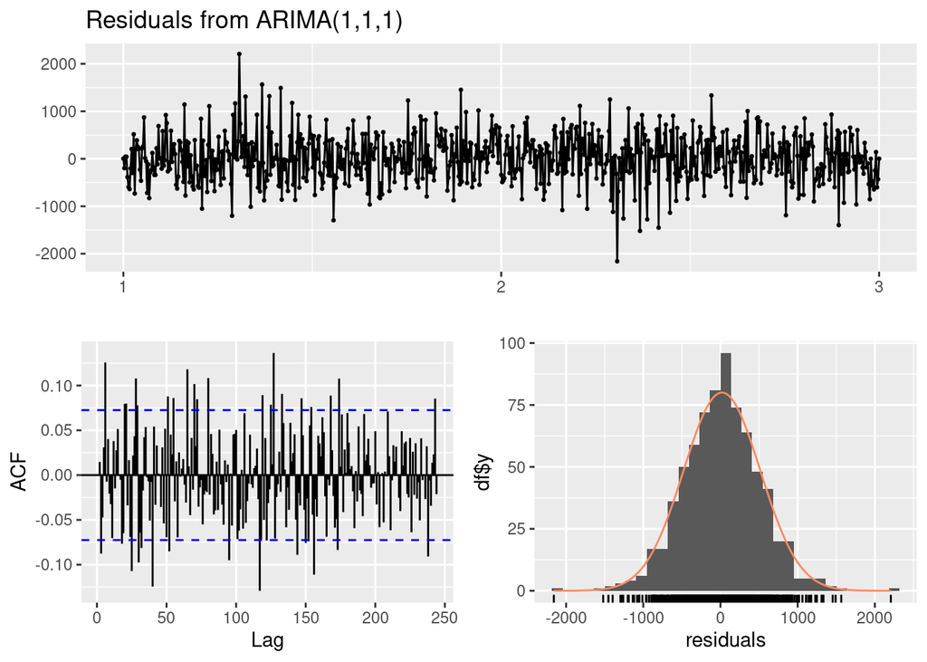

```
##
##  Ljung-Box test
##
## data:  Residuals from ARIMA(1,1,1)
## Q* = 339.68, df = 144, p-value < 2.2e-16
##
## Model df: 2.   Total lags used: 146
```

```r
# Residual diagnostics
checkresiduals(auto_fit)  # includes ACF and Ljung-Box test
```

```r
# Shapiro-Wilk Normality Test
shapiro.test(residuals(auto_fit))
```

```
##
##  Shapiro-Wilk normality test
##
## data:  residuals(auto_fit)
## W = 0.99452, p-value = 0.00982
```

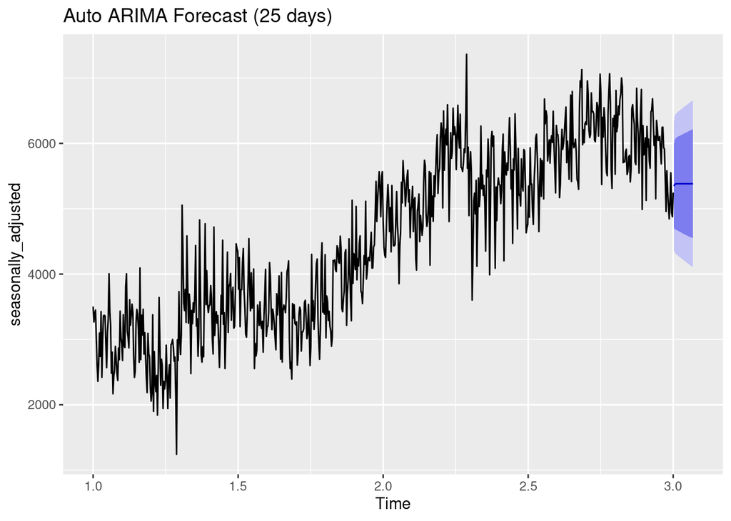

```r
# Forecast next 25 days
auto_forecast <- forecast(auto_fit, h = 25)
manual_forecast <- forecast(manual_fit, h = 25)

# Plot both
autoplot(auto_forecast) + labs(title = "Auto ARIMA Forecast (25 days)")
```

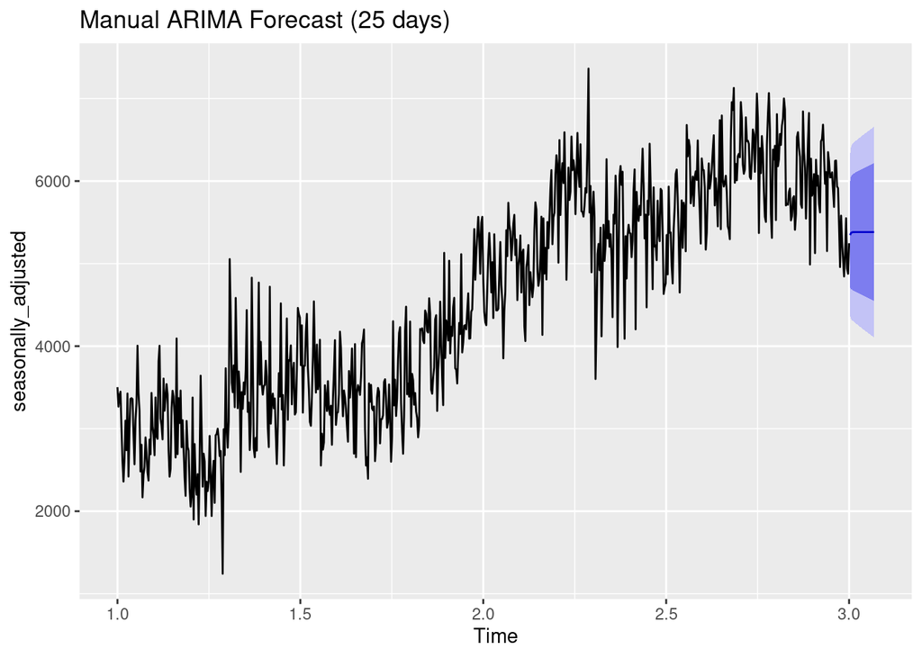

```r
autoplot(manual_forecast) + labs(title = "Manual ARIMA Forecast (25 days)")
```

# Task Six: Findings and Conclusions

## Findings and Conclusions

Throughout this project, I analyzed daily bike sharing rental data to understand patterns, smooth the time series, and build accurate forecasts.

## What I Did

- Explored daily rental trends and visualized patterns using time series plots.
- Cleaned the data using the tsclean() function to handle outliers and missing values.
- Applied Simple Moving Average and Simple Exponential Smoothing to smooth fluctuations.
- Decomposed the time series using STL to observe trend and seasonal components.
- Tested for stationarity using the Augmented Dickey-Fuller test, ACF, and PACF plots.
- Used differencing to make the series stationary when necessary.
- Built and compared Auto ARIMA and Manual ARIMA models.
- Generated 25-day forecasts and evaluated model performance based on residuals and AIC.

## Takeaways

- Time series decomposition is essential to understand the underlying structure of the data.
- Proper cleaning and transformation (seasonal adjustment, differencing) is necessary before modeling.
- Auto ARIMA is a powerful tool for quick and effective forecasting, but manual tuning gives more control.
- The final models provide realistic short-term forecasts that could help in planning inventory, workforce, and promotions for bike-sharing services.